# Dataset: Credit Card Approval Prediction

https://www.kaggle.com/rikdifos/credit-card-approval-prediction Accessed 11/12/2020

```python
! pip install lightgbm
! pip install catboost
```

```
  Using cached plotly-4.12.0-py2.py3-none-any.whl (13.1 MB)
Processing c:\users\em\appdata\local\pip\cache\wheels\f9\8d\8d\f6af3f7f9eea3553bc2fe6d53e4b287dad18b06a861ac56ddf\retrying-1.3.3-py3-none-any.whl
```

```python
# import libraries and data
%matplotlib inline
import warnings
warnings.filterwarnings('ignore')
import pandas as pd
import numpy as np
import matplotlib.pyplot as plt
import seaborn as sns
import statsmodels.api as sm

from sklearn.linear_model import LogisticRegression
from sklearn.tree import DecisionTreeClassifier
from sklearn.tree import plot_tree
from sklearn.model_selection import train_test_split
from sklearn.model_selection import cross_val_score
from sklearn.metrics import accuracy_score, confusion_matrix
from sklearn.metrics import plot_confusion_matrix
from sklearn import svm
from sklearn.ensemble import RandomForestClassifier
from sklearn.ensemble import RandomForestRegressor
from sklearn.tree import export_graphviz
from sklearn.metrics import precision_score, recall_score


import pydot
import itertools
import xgboost as xgb
from xgboost import XGBClassifier, plot_tree
from lightgbm import LGBMClassifier
from graphviz import Digraph

from catboost import CatBoostClassifier
```

```python
applications_df = pd.read_csv('application_record.csv')
```

```python
credit_df = pd.read_csv('credit_record.csv')
```

## Create target group where balance was overdue for more than 60 days

```python
# create column that we want to predict
credit_df['dep_value'] = None
credit_df['dep_value'][credit_df['STATUS'] =='2']='Yes'
credit_df['dep_value'][credit_df['STATUS'] =='3']='Yes'
credit_df['dep_value'][credit_df['STATUS'] =='4']='Yes'
credit_df['dep_value'][credit_df['STATUS'] =='5']='Yes'
```

```python
credit_df.head(2)
```

|  | ID | MONTHS_BALANCE | STATUS | dep_value |
| --- | --- | --- | --- | --- |
| 0 | 5001711 | 0 | X | None |
| 1 | 5001711 | -1 | 0 | None |

```python
# de-duplicate with groupby
resp=credit_df.groupby('ID').count()
resp['dep_value'][resp['dep_value'] > 0]='Yes'
resp['dep_value'][resp['dep_value'] == 0]='No'
resp = resp[['dep_value']]
resp.head(2)
```

| ID | dep_value |
| --- | --- |
| 5001711 | No |
| 5001712 | No |

```python
# merge datasets
df=pd.merge(applications_df,resp,how='inner',on='ID')
df['target']=df['dep_value']
df.loc[df['target']=='Yes','target']=1
df.loc[df['target']=='No','target']=0
df.head(2)
```

|  | ID | CODE_GENDER | FLAG_OWN_CAR | FLAG_OWN_REALTY | CNT_CHILDREN | AMT_INCOME_TOTAL | NAME_INCOME_TYPE | NAME_EDUCATION_TYPE | NAME_FAMILY_STATUS | NAME_HOUSING_TYPE | DAYS_BIRTH | DAYS_EMPLOYED | FLAG_MOBIL | FLAG_WORK_PHONE | FLAG_PHONE | FLAG_EMAIL | OCCUPATION_TYPE | CNT_FAM_MEMBERS | dep_value | target |
| --- | --- | --- | --- | --- | --- | --- | --- | --- | --- | --- | --- | --- | --- | --- | --- | --- | --- | --- | --- | --- |
| 0 | 5008804 | M | Y | Y | 0 | 427500.0 | Working | Higher education | Civil marriage | Rented apartment | -12005 | -4542 | 1 | 1 | 0 | 0 | NaN | 2.0 | No | 0 |
| 1 | 5008805 | M | Y | Y | 0 | 427500.0 | Working | Higher education | Civil marriage | Rented apartment | -12005 | -4542 | 1 | 1 | 0 | 0 | NaN | 2.0 | No | 0 |

```python
# Address missing data
df.dropna()
df = df.mask(df == 'NULL').dropna()
```

```python
print(resp['dep_value'].value_counts())
resp['dep_value'].value_counts(normalize=True)
```

```
No     45318
Yes      667
Name: dep_value, dtype: int64
```

```
No     0.985495
Yes    0.014505
Name: dep_value, dtype: float64
```

## Other Feature Engineering

Format data in dataset X

```python
#rename columns
df.rename(columns={'CODE_GENDER':'Gender','FLAG_OWN_CAR':'Car','FLAG_OWN_REALTY':'Reality','CNT_CHILDREN':'Children','AMT_INCOME_TOTAL':'income',
'NAME_EDUCATION_TYPE':'education','NAME_HOUSING_TYPE':'housing','FLAG_EMAIL':'email','NAME_INCOME_TYPE':'income_type','CNT_FAM_MEMBERS':'family_size','OCCUPATION_TYPE':'occupation'
},inplace=True)
```

```python
# add column for age in years
df['age'] = df['DAYS_BIRTH']/-365
```

```python
# add column for years in workforce
df['years_working'] = df['DAYS_EMPLOYED']/-365
```

```python
# drop columns we aren't going to use
df = df.drop(columns={'ID', 'FLAG_MOBIL', 'FLAG_WORK_PHONE', 'FLAG_PHONE', 'email', 'DAYS_BIRTH', 'DAYS_EMPLOYED', 'dep_value', 'occupation', 'NAME_FAMILY_STATUS'})
df.head(2)
```

|  | Gender | Car | Reality | Children | income | income_type | education | housing | family_size | target | age | years_working |
| --- | --- | --- | --- | --- | --- | --- | --- | --- | --- | --- | --- | --- |
| 2 | M | Y | Y | 0 | 112500.0 | Working | Secondary / secondary special | House / apartment | 2.0 | 0 | 58.832877 | 3.106849 |
| 3 | F | N | Y | 0 | 270000.0 | Commercial associate | Secondary / secondary special | House / apartment | 1.0 | 0 | 52.356164 | 8.358904 |

#### Address Binary Data

```python
# replace M/F with 0/1
df['Gender'] = df['Gender'].replace(['F','M'],[1,0])
print(df['Gender'].value_counts())
```

```
1    15630
0     9504
Name: Gender, dtype: int64
```

```python
# replace car flag with 0/1
df['Car'] = df['Car'].replace(['N','Y'],[0,1])
print(df['Car'].value_counts())
```

```
0    14618
1    10516
Name: Car, dtype: int64
```

```python
# replace realty with 0/1
df['Reality'] = df['Reality'].replace(['N','Y'],[0,1])
print(df['Reality'].value_counts())
```

```
1    16461
0     8673
Name: Reality, dtype: int64
```

```python
df.head(2)
```

|  | Gender | Car | Reality | Children | income | income_type | education | housing | family_size | target | age | years_working |
| --- | --- | --- | --- | --- | --- | --- | --- | --- | --- | --- | --- | --- |
| 2 | 0 | 1 | 1 | 0 | 112500.0 | Working | Secondary / secondary special | House / apartment | 2.0 | 0 | 58.832877 | 3.106849 |
| 3 | 1 | 0 | 1 | 0 | 270000.0 | Commercial associate | Secondary / secondary special | House / apartment | 1.0 | 0 | 52.356164 | 8.358904 |

### Address Categorical Data

```python
# Convert continuous income to category
df['income'] = pd.cut(df['income'], bins=3, labels=["low", "medium", "high"])
df.head(2)
```

|  | Gender | Car | Reality | Children | income | income_type | education | housing | family_size | target | age | years_working |
| --- | --- | --- | --- | --- | --- | --- | --- | --- | --- | --- | --- | --- |
| 2 | 0 | 1 | 1 | 0 | low | Working | Secondary / secondary special | House / apartment | 2.0 | 0 | 58.832877 | 3.106849 |
| 3 | 1 | 0 | 1 | 0 | low | Commercial associate | Secondary / secondary special | House / apartment | 1.0 | 0 | 52.356164 | 8.358904 |

```python
# Convert continuous Children to category
df.loc[df['Children'] >= 2,'Children']='2orMore'
print(df['Children'].value_counts(sort=False))
```

```
0          15908
1           6118
2orMore     3108
Name: Children, dtype: int64
```

```python
# Convert continuous Family Size to category
df.loc[df['family_size'] >= 3,'family_size']='3orMore'
print(df['family_size'].value_counts(sort=False))
```

```
1.0         4263
2.0        12697
3orMore     8174
Name: family_size, dtype: int64
```

```python
# Convert continuous Age to category
df['age'] = pd.cut(df['age'], bins=3, labels=["young", "middle_age", "older"])
df.head()
```

|  | Gender | Car | Reality | Children | income | income_type | education | housing | family_size | target | age | years_working |
| --- | --- | --- | --- | --- | --- | --- | --- | --- | --- | --- | --- | --- |
| 2 | 0 | 1 | 1 | 0 | low | Working | Secondary / secondary special | House / apartment | 2 | 0 | older | 3.106849 |
| 3 | 1 | 0 | 1 | 0 | low | Commercial associate | Secondary / secondary special | House / apartment | 1 | 0 | older | 8.358904 |
| 4 | 1 | 0 | 1 | 0 | low | Commercial associate | Secondary / secondary special | House / apartment | 1 | 0 | older | 8.358904 |
| 5 | 1 | 0 | 1 | 0 | low | Commercial associate | Secondary / secondary special | House / apartment | 1 | 0 | older | 8.358904 |
| 6 | 1 | 0 | 1 | 0 | low | Commercial associate | Secondary / secondary special | House / apartment | 1 | 0 | older | 8.358904 |

```python
# Convert continuous Years Working to category
df['years_working'] = pd.cut(df['years_working'], bins=3, labels=["entry", "mid_career", "seasoned"])
df.head()
```

|  | Gender | Car | Reality | Children | income | income_type | education | housing | family_size | target | age | years_working |
| --- | --- | --- | --- | --- | --- | --- | --- | --- | --- | --- | --- | --- |
| 2 | 0 | 1 | 1 | 0 | low | Working | Secondary / secondary special | House / apartment | 2 | 0 | older | entry |
| 3 | 1 | 0 | 1 | 0 | low | Commercial associate | Secondary / secondary special | House / apartment | 1 | 0 | older | entry |
| 4 | 1 | 0 | 1 | 0 | low | Commercial associate | Secondary / secondary special | House / apartment | 1 | 0 | older | entry |
| 5 | 1 | 0 | 1 | 0 | low | Commercial associate | Secondary / secondary special | House / apartment | 1 | 0 | older | entry |
| 6 | 1 | 0 | 1 | 0 | low | Commercial associate | Secondary / secondary special | House / apartment | 1 | 0 | older | entry |

```python
# convert all categories to binary
df = pd.get_dummies(df, columns=['income_type',
                                    'education',
                                    'housing',
                                      'income',
                                      'Children',
                                      'family_size',
                                      'age',
                                      'years_working'])
df.head()
```

|  | Gender | Car | Reality | target | income_type_Commercial associate | income_type_Pensioner | income_type_State servant | income_type_Student | income_type_Working | education_Academic degree | ... | Children_2orMore | family_size_1.0 | family_size_2.0 | family_size_3orMore | age_young | age_middle_age | age_older | years_working_entry | years_working_mid_career | years_working_seasoned |
| --- | --- | --- | --- | --- | --- | --- | --- | --- | --- | --- | --- | --- | --- | --- | --- | --- | --- | --- | --- | --- | --- |
| 2 | 0 | 1 | 1 | 0 | 0 | 0 | 0 | 0 | 1 | 0 | ... | 0 | 0 | 1 | 0 | 0 | 0 | 1 | 1 | 0 | 0 |
| 3 | 1 | 0 | 1 | 0 | 1 | 0 | 0 | 0 | 0 | 0 | ... | 0 | 1 | 0 | 0 | 0 | 0 | 1 | 1 | 0 | 0 |
| 4 | 1 | 0 | 1 | 0 | 1 | 0 | 0 | 0 | 0 | 0 | ... | 0 | 1 | 0 | 0 | 0 | 0 | 1 | 1 | 0 | 0 |
| 5 | 1 | 0 | 1 | 0 | 1 | 0 | 0 | 0 | 0 | 0 | ... | 0 | 1 | 0 | 0 | 0 | 0 | 1 | 1 | 0 | 0 |
| 6 | 1 | 0 | 1 | 0 | 1 | 0 | 0 | 0 | 0 | 0 | ... | 0 | 1 | 0 | 0 | 0 | 0 | 1 | 1 | 0 | 0 |

5 rows × 35 columns

```python
df.info()
```

```
<class 'pandas.core.frame.DataFrame'>
Int64Index: 25134 entries, 2 to 36456
Data columns (total 35 columns):
 #   Column                                   Non-Null Count  Dtype
---  ------                                   --------------  -----
 0   Gender                                   25134 non-null  int64
 1   Car                                      25134 non-null  int64
 2   Reality                                  25134 non-null  int64
 3   target                                   25134 non-null  object
 4   income_type_Commercial associate         25134 non-null  uint8
 5   income_type_Pensioner                    25134 non-null  uint8
 6   income_type_State servant                25134 non-null  uint8
 7   income_type_Student                      25134 non-null  uint8
 8   income_type_Working                      25134 non-null  uint8
 9   education_Academic degree                25134 non-null  uint8
```

[output cut: 27 more lines]

```python
df.columns = ['Gender',
                     'Car',
                     'Reality',
                     'target',
                     'income_type_Commercial',
                     'income_type_Pensioner',
                     'income_type_State',
                     'income_type_Student',
                     'income_type_Working',
                     'education_degree',
                     'education_Higher_ed',
                     'education_Incomplete_higher',
                     'education_Lower_secondary',
                     'education_Secondary',
                     'housing_apartment',
                     'housing_house',
                     'housing_municipal',
                     'housing_office_apartment',
                     'housing_rented_apartment',
                     'housing_parents',
                     'income_low',
                     'income_medium',
                     'income_high',
                     'Children_0',
                     'Children_1',
                     'Children_2orMore',
                     'family_size_1',
                     'family_size_2',
                     'family_size_3orMore',
                     'age_young',
                     'age_middle',
                     'age_older',
                     'years_working_entry',
                     'years_working_mid_career',
                     'years_working_seasoned',

]
```

```python
df['income_type_Commercial'] = df.income_type_Commercial.astype('int64')
df['income_type_Pensioner'] = df.income_type_Pensioner.astype('int64')
df['income_type_State'] = df.income_type_State.astype('int64')
df['income_type_Student'] = df.income_type_Student.astype('int64')
df['income_type_Working'] = df.income_type_Working.astype('int64')
df['education_degree'] = df.education_degree.astype('int64')
df['education_Higher_ed'] = df.education_Higher_ed.astype('int64')
df['education_Incomplete_higher'] = df.education_Incomplete_higher.astype('int64')
df['education_Lower_secondary'] = df.education_Lower_secondary.astype('int64')
df['education_Secondary'] = df.education_Secondary.astype('int64')
df['housing_apartment'] = df.housing_apartment.astype('int64')
df['housing_house'] = df.housing_house.astype('int64')
df['housing_municipal'] = df.housing_municipal.astype('int64')
df['housing_office_apartment'] = df.housing_office_apartment.astype('int64')
df['housing_rented_apartment'] = df.housing_rented_apartment.astype('int64')
df['housing_parents'] = df.housing_parents.astype('int64')
df['income_low'] = df.income_low.astype('int64')
df['income_medium'] = df.income_medium.astype('int64')
df['income_high'] = df.income_high.astype('int64')
df['Children_0'] = df.Children_0.astype('int64')
df['Children_1'] = df.Children_1.astype('int64')
df['Children_2orMore'] = df.Children_2orMore.astype('int64')
df['family_size_1'] = df.family_size_1.astype('int64')
df['family_size_2'] = df.family_size_2.astype('int64')
df['family_size_3orMore'] = df.family_size_3orMore.astype('int64')
df['age_young'] = df.age_young.astype('int64')
df['age_middle'] = df.age_middle.astype('int64')
df['age_older'] = df.age_older.astype('int64')
df['years_working_entry'] = df.years_working_entry.astype('int64')
df['years_working_mid_career'] = df.years_working_mid_career.astype('int64')
df['years_working_seasoned'] = df.years_working_seasoned.astype('int64')
```

```python
df.info()
```

```
<class 'pandas.core.frame.DataFrame'>
Int64Index: 25134 entries, 2 to 36456
Data columns (total 35 columns):
 #   Column                       Non-Null Count  Dtype
---  ------                       --------------  -----
 0   Gender                       25134 non-null  int64
 1   Car                          25134 non-null  int64
 2   Reality                      25134 non-null  int64
 3   target                       25134 non-null  object
 4   income_type_Commercial       25134 non-null  int64
 5   income_type_Pensioner        25134 non-null  int64
 6   income_type_State            25134 non-null  int64
 7   income_type_Student          25134 non-null  int64
 8   income_type_Working          25134 non-null  int64
 9   education_degree             25134 non-null  int64
```

[output cut: 27 more lines]

## Information Gain

For each feature, calculate entropy among levels

```python
# Will come back to this for final project (or assignment 3 if time)
```

## Split Data into Dependent and Independent Variables

```python
# columns of data we will use to make classifications
X_encoded = df.drop('target', axis=1).copy()
X_encoded.head(2)
```

|  | Gender | Car | Reality | income_type_Commercial | income_type_Pensioner | income_type_State | income_type_Student | income_type_Working | education_degree | education_Higher_ed | ... | Children_2orMore | family_size_1 | family_size_2 | family_size_3orMore | age_young | age_middle | age_older | years_working_entry | years_working_mid_career | years_working_seasoned |
| --- | --- | --- | --- | --- | --- | --- | --- | --- | --- | --- | --- | --- | --- | --- | --- | --- | --- | --- | --- | --- | --- |
| 2 | 0 | 1 | 1 | 0 | 0 | 0 | 0 | 1 | 0 | 0 | ... | 0 | 0 | 1 | 0 | 0 | 0 | 1 | 1 | 0 | 0 |
| 3 | 1 | 0 | 1 | 1 | 0 | 0 | 0 | 0 | 0 | 0 | ... | 0 | 1 | 0 | 0 | 0 | 0 | 1 | 1 | 0 | 0 |

2 rows × 34 columns

```python
# what we want to predict
y = df['target'].copy()

# Got error: ValueError: Unknown label type: 'unknown' when fitting models later
# because y is of type object, sklearn cannot recognize it.
y=y.astype('int64')
y.head()
```

```
2    0
3    0
4    0
5    0
6    0
Name: target, dtype: int64
```

## Regression

Will come back to this for final project (or assignment 3 if time):

https://scikit-learn.org/stable/modules/linear_model.html#logistic-regression https://scikit-learn.org/stable/modules/generated/sklearn.linear_model.LogisticRegression.html

Compute Class Weight: https://scikit-learn.org/stable/modules/generated/sklearn.utils.class_weight.compute_class_weight.html

Cost-Sensitive Logistic Regression for Imbalanced Classification: https://machinelearningmastery.com/cost-sensitive-logistic-regression/

```python
# add heatmaps and other visualizations for final project
# Bar chart of features sorted by information gain, etc.
```

# Decision Tree

```python
# Split data into training and testing
X_train, X_test, y_train, y_test = train_test_split(X_encoded, y, random_state = 1024)

print("train ratio =", sum(y_train)/ len(y_train))
print("test ratio =", sum(y_test)/ len(y_test))
```

```
train ratio = 0.017135278514588858
test ratio = 0.01575429662635264
```

```python
%%time
X_train, X_test, y_train, y_test = train_test_split(X_encoded, y, random_state = 1024)

clf_dt = DecisionTreeClassifier(random_state=1024)
clf_dt = clf_dt.fit(X_train, y_train)
y_predict = clf_dt.predict(X_test)

print(pd.DataFrame(confusion_matrix(y_test,y_predict)))
```

```
      0  1
0  6179  6
1    90  9
Wall time: 61.8 ms
```

```python
print('Accuracy Score is {:.5}'.format(accuracy_score(y_test, y_predict)))
# precision = (TP) / (TP+FP)
print('Precision Score is {:.5}'.format(precision_score(y_test, y_predict)))
# recall = (TP) / (TP+FN)
print('Recall Score is {:.5}'.format(recall_score(y_test, y_predict)))
```

```
Accuracy Score is 0.98472
Precision Score is 0.6
Recall Score is 0.090909
```

```
<sklearn.metrics._plot.confusion_matrix.ConfusionMatrixDisplay at 0x1307b67bc08>
```

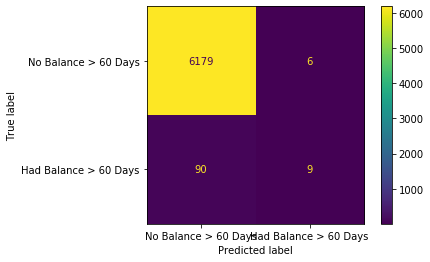

```python
# View confusion matrix for preliminary tree
plot_confusion_matrix(clf_dt, X_test, y_test, display_labels=["No Balance > 60 Days", "Had Balance > 60 Days"])
```

From the test data confusion matrix, we see that of the 6185 people that never had an overdue balance for more than 60 days, 6179 were correctly classified. And of the 99 people who had a balance due for over 60 days, 9 were correctly classified.

To improve bias-variance trade-off, we will try lasso and pruning.

## Lasso and/or Ridge Regression

```python
# Will come back to this for final project (or assignment 3 if time)
```

Come back to other **optimization techniques/hyper-parameter tuning**: https://scikit-learn.org/stable/modules/grid_search.html

## Pruning

```python
path = clf_dt.cost_complexity_pruning_path(X_train, y_train)
ccp_alphas, impurities = path.ccp_alphas, path.impurities
ccp_alphas = ccp_alphas[:-1]

clf_dts = []
for ccp_alpha in ccp_alphas:
    clf_dt = DecisionTreeClassifier(random_state=1024, ccp_alpha=ccp_alpha)
    clf_dt.fit(X_train, y_train)
    clf_dts.append(clf_dt)
```

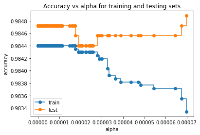

```python
# plot accuracy
train_scores = [clf_dt.score(X_train, y_train) for clf_dt in clf_dts]
test_scores = [clf_dt.score(X_test, y_test) for clf_dt in clf_dts]

fig, ax = plt.subplots()
ax.set_xlabel("alpha")
ax.set_ylabel("accuracy")
ax.set_title("Accuracy vs alpha for training and testing sets")
ax.plot(ccp_alphas, train_scores, marker='o', label="train", drawstyle="steps-post")
ax.plot(ccp_alphas, test_scores, marker='o', label="test", drawstyle="steps-post")
ax.legend()
plt.show()
```

Results show highest accuracy with alpha closer to 0.00007 (needs review?)

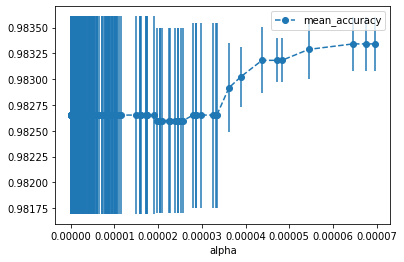

```python
%%time
# use cross validation to find best alpha
alpha_loop_values = []
for ccp_alpha in ccp_alphas:
    clf_dt = DecisionTreeClassifier(random_state=0, ccp_alpha=ccp_alpha)
    scores = cross_val_score(clf_dt, X_train, y_train, cv=5)
    alpha_loop_values.append([ccp_alpha, np.mean(scores), np.std(scores)])

alpha_results = pd.DataFrame(alpha_loop_values,
                             columns=['alpha', 'mean_accuracy', 'std'])

alpha_results.plot(x='alpha',
                   y='mean_accuracy',
                   yerr='std',
                   marker='o',
                   linestyle='--')
```

Using cross validation, we see that alpha may be more accurate somewhere between 0.00006 and 0.00007.

```python
# Find exact value
alpha_results[(alpha_results['alpha'] > 0.00006)
             &
             (alpha_results['alpha'] < 0.00007)]
```

|  | alpha | mean_accuracy | std |
| --- | --- | --- | --- |
| 265 | 0.000065 | 0.983342 | 0.00026 |
| 266 | 0.000068 | 0.983342 | 0.00026 |
| 267 | 0.000070 | 0.983342 | 0.00026 |

```python
# Store ideal value
#ideal_ccp_alpha = alpha_results[(alpha_results['alpha'] > 0.00006)
#                               &
#                               (alpha_results['alpha'] < 0.00007)]['alpha']
#ideal_ccp_alpha
```

```python
ideal_ccp_alpha = 0.000065
```

### Run Decision Tree again using ideal alpha

```python
%%time
clf_dt_pruned = DecisionTreeClassifier(random_state=1024,
                                       ccp_alpha=ideal_ccp_alpha)
clf_dt_pruned = clf_dt_pruned.fit(X_train, y_train)
y_predict_pruned = clf_dt_pruned.predict(X_test)

print(pd.DataFrame(confusion_matrix(y_test,y_predict_pruned)))
```

```
      0  1
0  6182  3
1    94  5
Wall time: 47.9 ms
```

```
<sklearn.metrics._plot.confusion_matrix.ConfusionMatrixDisplay at 0x13079591808>
```

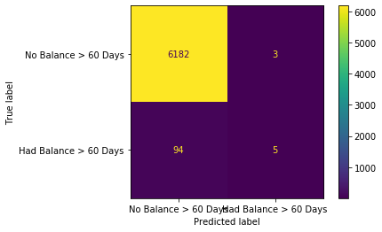

```python
# confusion matrix
plot_confusion_matrix(clf_dt_pruned,
                      X_test,
                      y_test,
                      display_labels=["No Balance > 60 Days", "Had Balance > 60 Days"])
```

```python
print('Accuracy Score is {:.5}'.format(accuracy_score(y_test, y_predict)))
# precision = (TP) / (TP+FP)
print('Precision Score is {:.5}'.format(precision_score(y_test, y_predict)))
# recall = (TP) / (TP+FN)
print('Recall Score is {:.5}'.format(recall_score(y_test, y_predict)))
```

```
Accuracy Score is 0.98472
Precision Score is 0.6
Recall Score is 0.090909
```

From the test data confusion matrix, we see that bias-variance trade-off got worse... will need to revisit.

Continuing on in assignment to document code needed.

```
[Text(1281.65625, 774.63, 'income_type_Pensioner <= 0.5\ngini = 0.034\nsamples = 18850\nvalue = [18527, 323]\nclass = No Overdue'),
```

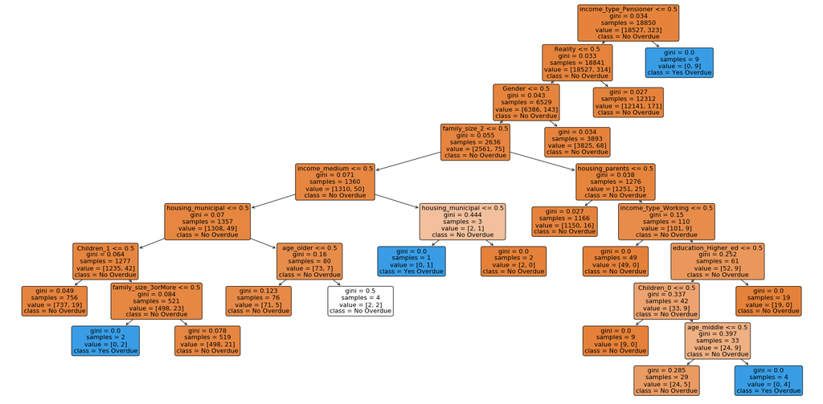

```python
# Draw Decision Tree
plt.figure(figsize=(30,15))
plot_tree(clf_dt_pruned,
           filled=True,
         rounded=True,
          class_names=["No Overdue", "Yes Overdue"],
          feature_names=X_encoded.columns)
```

```python
# will come back to Decision Tree
# more/better pruning needed
# or lasso/other method needed
```

# Random Forest

```python
%%time
clf_rf = RandomForestClassifier(n_estimators=250,
                              max_depth=12,
                              min_samples_leaf=16
                              )
clf_rf.fit(X_train, y_train)
y_predict = clf_rf.predict(X_test)

print(pd.DataFrame(confusion_matrix(y_test,y_predict)))
```

```
      0  1
0  6185  0
1    99  0
Wall time: 1.7 s
```

```python
print('Accuracy Score is {:.5}'.format(accuracy_score(y_test, y_predict)))
# precision = (TP) / (TP+FP)
print('Precision Score is {:.5}'.format(precision_score(y_test, y_predict)))
# recall = (TP) / (TP+FN)
print('Recall Score is {:.5}'.format(recall_score(y_test, y_predict)))
```

```
Accuracy Score is 0.98425
Precision Score is 0.0
Recall Score is 0.0
```

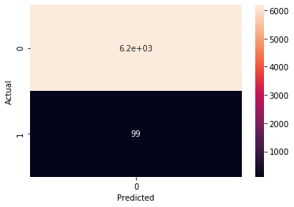

```python
#variable name same as function will cause error: TypeError 'DataFrame' object is not callable
clf_rf_matrix = pd.crosstab(y_test, y_predict, rownames=['Actual'], colnames=['Predicted'])
sns.heatmap(clf_rf_matrix, annot=True)
```

```python
'''
plot_confusion_matrix(confusion_matrix(y_test,y_predict),
                      classes=class_names, normalize = True,
                      title='Normalized Confusion Matrix: Ramdom Forests')
'''
```

```
"\nplot_confusion_matrix(confusion_matrix(y_test,y_predict),\n                      classes=class_names, normalize = True, \n                      title='Normalized Confusion Matrix: Ramdom Forests')\n"
```

# GBM —— lightGBM

```python
# Checking if the data is imbalanced or not
sum(y)/ len(y)
# 1.68% of the applicants are target users. We need to make sure we maintain the same % across training and testing datasets.
# It's called "stratification": split the data to maintain the ratio.
```

```
0.01679000557014403
```

```python
from imblearn.over_sampling import SMOTE

# Using Synthetic Minority Over-Sampling Technique(SMOTE) to overcome sample imbalance problem.
X_balance,Y_balance = SMOTE().fit_sample(X_encoded,y)
X_balance = pd.DataFrame(X_balance, columns = X_encoded.columns)

X_train, X_test, y_train, y_test = train_test_split(X_balance,Y_balance,
                                                    stratify=Y_balance, test_size=0.3,
                                                    random_state = 1024)
```

```python
%%time
from lightgbm import LGBMClassifier
clf_gbm = LGBMClassifier(num_leaves=35,
                       max_depth=8,
                       learning_rate=0.02,
                       n_estimators=250,
                       subsample = 0.8,
                       colsample_bytree =0.8
                      )
clf_gbm.fit(X_train, y_train)
y_predict = clf_gbm.predict(X_test)

print(pd.DataFrame(confusion_matrix(y_test,y_predict)))
```

```
      0     1
0  5811  1603
1   727  6687
Wall time: 576 ms
```

```python
print('Accuracy Score is {:.5}'.format(accuracy_score(y_test, y_predict)))
# precision = (TP) / (TP+FP)
print('Precision Score is {:.5}'.format(precision_score(y_test, y_predict)))
# recall = (TP) / (TP+FN)
print('Recall Score is {:.5}'.format(recall_score(y_test, y_predict)))
```

```
Accuracy Score is 0.84286
Precision Score is 0.80663
Recall Score is 0.90194
```

```
<sklearn.metrics._plot.confusion_matrix.ConfusionMatrixDisplay at 0x13001e7d9c8>
```

[figure not shown]

```python
# Confusion Matrix on the test data
plot_confusion_matrix(clf_gbm,
                      X_test,
                      y_test,
                      values_format='d',
                      display_labels=["No Balance > 60 Days", "Had Balance > 60 Days"])
```

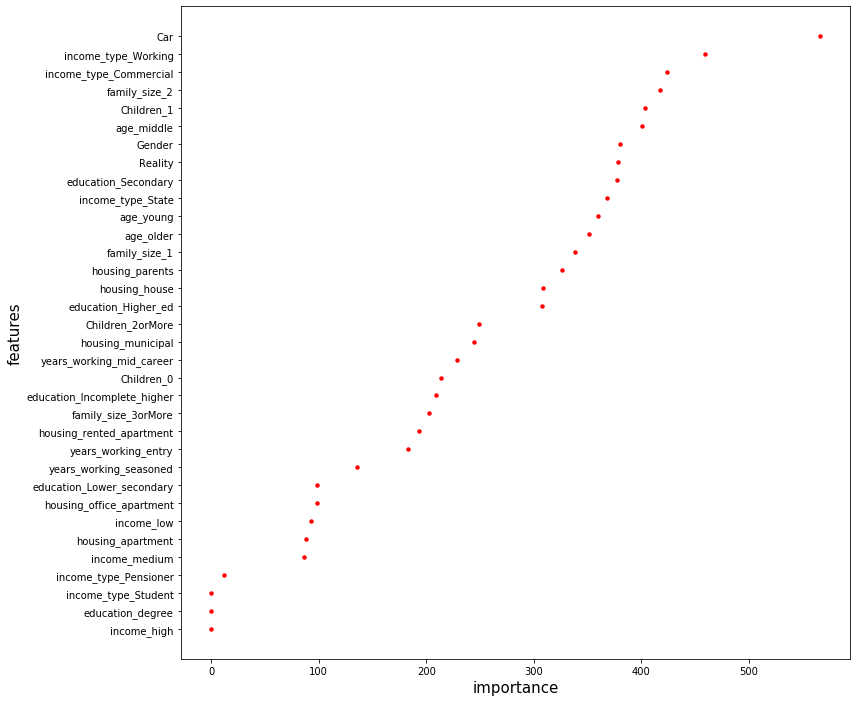

```python
#Showing important features:

def plot_importance(classifer, x_train, point_size = 25):
    #plot feature importance
    values = sorted(zip(x_train.columns, classifer.feature_importances_), key = lambda x: x[1] * -1)
    imp = pd.DataFrame(values,columns = ["Name", "Score"])
    imp.sort_values(by = 'Score',inplace = True)
    b = sns.scatterplot(x = 'Score',y='Name', linewidth = 0,
                data = imp,s = point_size, color='red')
    fig = plt.gcf()
    fig.set_size_inches(12, 12) # Change plot size
    b.set_xlabel("importance",fontsize=15)
    b.set_ylabel("features",fontsize=15)
    b.tick_params(labelsize=10)

plot_importance(clf_gbm, X_train,20)
```

# XGBoost

```python
%%time
import xgboost as xgb

# Creating the XGBClassfier shell
clf_xgb = xgb.XGBClassifier(objective='binary:logistic', missing=None, seed=42)

'''
Instead of finding the optimal number of tress using K-Cross Validation,
we use early stopping to stop the tree when the cost function no longer reduces.
XGBoost will do the cross validation; we just have to specifiy the
number of rounds to exhaust with no improvement before stopping.
We use evaluation metric as Area Under Precision-Recall Curve
'''

clf_xgb.fit(X_train,
            y_train,
            verbose=True,
            early_stopping_rounds=10,
            eval_metric='aucpr',
            eval_set=[(X_test, y_test)])

# After building 99 trees, the model doesn't improve any longer. base_score=0.5
# So we check for the next 10 iterations and stop.

# make predictions for test data
y_predict = clf_xgb.predict(X_test)

# evaluate predictions
print(pd.DataFrame(confusion_matrix(y_test,y_predict)))
```

```
Will train until validation_0-aucpr hasn't improved in 10 rounds.
      0     1
0  5940  1474
1   502  6912
Wall time: 2.07 s
```

```python
print('Accuracy Score is {:.5}'.format(accuracy_score(y_test, y_predict)))
# precision = (TP) / (TP+FP)
print('Precision Score is {:.5}'.format(precision_score(y_test, y_predict)))
# recall = (TP) / (TP+FN)
print('Recall Score is {:.5}'.format(recall_score(y_test, y_predict)))
```

```
Accuracy Score is 0.86674
Precision Score is 0.82423
Recall Score is 0.93229
```

```
<sklearn.metrics._plot.confusion_matrix.ConfusionMatrixDisplay at 0x130061e9208>
```

[figure not shown]

```python
# Confusion Matrix on the test data
plot_confusion_matrix(clf_xgb,
                      X_test,
                      y_test,
                      values_format='d',
                      display_labels=["No Balance > 60 Days", "Had Balance > 60 Days"])
```

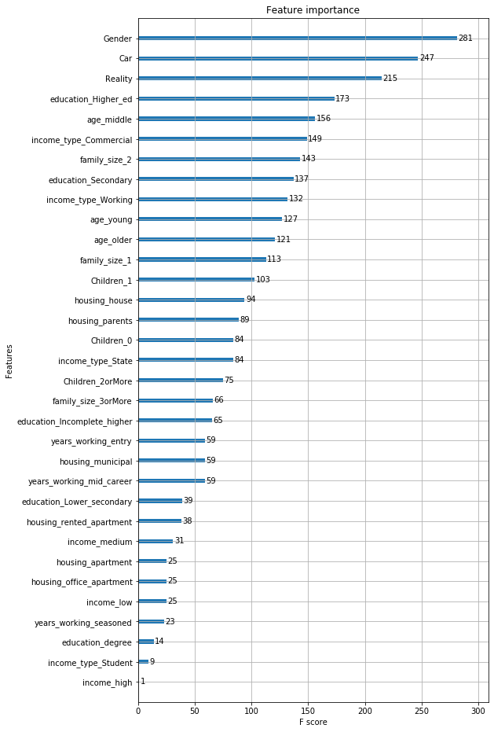

```python
xgb.plot_importance(clf_xgb)
plt.rcParams['figure.figsize'] = [8, 15]
plt.show()
```

[output not shown]

[figure not shown]

```python
## graphviz got issue with my laptop's system and unavilable for a while.
## to prevent more time consumption, will leave this graph out of the project for now
from xgboost import plot_tree
from graphviz import Digraph

# Draw XGBoost Tree
fig = plt.figure(figsize=(10, 10))
ax = fig.subplots()
xgb.plot_tree(clf_xgb, num_trees=20, ax=ax)
plt.show()

# CalledProcessError: Command '['dot', '-Tpng']' returned non-zero exit status 4294967295
```

# References

https://www.kaggle.com/rikdifos/credit-card-approval-prediction/discussion/119320

https://www.kaggle.com/srvkarn/credit-card-approval-prediction-using-ml

https://www.kaggle.com/storrinha/st-00-data-exploration-v1

https://xgboost.readthedocs.io/en/latest/python/python_intro.html#data-interface

https://xgboost.readthedocs.io/en/latest/parameter.html